# HEART ATTACK ANALYSIS AND PREDICTION

```python
import pandas as pd
import numpy as np
import matplotlib.pyplot as plt
import seaborn as sns
import warnings
warnings.filterwarnings('ignore')
```

About this dataset Age : Age of the patient

Sex : Sex of the patient

exang: exercise induced angina (1 = yes; 0 = no)

ca: number of major vessels (0-3)

cp : Chest Pain type chest pain type

Value 1: typical angina Value 2: atypical angina Value 3: non-anginal pain Value 4: asymptomatic trtbps : resting blood pressure (in mm Hg)

chol : cholestoral in mg/dl fetched via BMI sensor

fbs : (fasting blood sugar > 120 mg/dl) (1 = true; 0 = false)

rest_ecg : resting electrocardiographic results

thalachh : maximum heart rate achieved

exng : exercise induced angina (1 = yes; 0 = no)

oldpeak : Previous peak

Value 0: normal Value 1: having ST-T wave abnormality (T wave inversions and/or ST elevation or depression of > 0.05 mV) Value 2: showing probable or definite left ventricular hypertrophy by Estes' criteria thalach : maximum heart rate achieved

target : 0= less chance of heart attack 1= more chance of heart attack

```python
df= pd.read_csv('Desktop\heart.csv')
df.head()
```

|  | age | sex | cp | trtbps | chol | fbs | restecg | thalachh | exng | oldpeak | slp | caa | thall | output |
| --- | --- | --- | --- | --- | --- | --- | --- | --- | --- | --- | --- | --- | --- | --- |
| 0 | 63 | 1 | 3 | 145 | 233 | 1 | 0 | 150 | 0 | 2.3 | 0 | 0 | 1 | 1 |
| 1 | 37 | 1 | 2 | 130 | 250 | 0 | 1 | 187 | 0 | 3.5 | 0 | 0 | 2 | 1 |
| 2 | 41 | 0 | 1 | 130 | 204 | 0 | 0 | 172 | 0 | 1.4 | 2 | 0 | 2 | 1 |
| 3 | 56 | 1 | 1 | 120 | 236 | 0 | 1 | 178 | 0 | 0.8 | 2 | 0 | 2 | 1 |
| 4 | 57 | 0 | 0 | 120 | 354 | 0 | 1 | 163 | 1 | 0.6 | 2 | 0 | 2 | 1 |

# Checking for missing values

```python
df.isnull().sum()
```

```
age         0
sex         0
cp          0
trtbps      0
chol        0
fbs         0
restecg     0
thalachh    0
exng        0
oldpeak     0
slp         0
caa         0
thall       0
output      0
dtype: int64
```

There are no missing values

# Data exploration

```python
df.info()
```

```
<class 'pandas.core.frame.DataFrame'>
RangeIndex: 303 entries, 0 to 302
Data columns (total 14 columns):
 #   Column    Non-Null Count  Dtype
---  ------    --------------  -----
 0   age       303 non-null    int64
 1   sex       303 non-null    int64
 2   cp        303 non-null    int64
 3   trtbps    303 non-null    int64
 4   chol      303 non-null    int64
 5   fbs       303 non-null    int64
 6   restecg   303 non-null    int64
 7   thalachh  303 non-null    int64
 8   exng      303 non-null    int64
 9   oldpeak   303 non-null    float64
 10  slp       303 non-null    int64
 11  caa       303 non-null    int64
 12  thall     303 non-null    int64
 13  output    303 non-null    int64
dtypes: float64(1), int64(13)
memory usage: 33.3 KB
```

All features are numeric Let's check how these values relate to each other.

```python
df.describe()
```

|  | age | sex | cp | trtbps | chol | fbs | restecg | thalachh | exng | oldpeak | slp | caa | thall | output |
| --- | --- | --- | --- | --- | --- | --- | --- | --- | --- | --- | --- | --- | --- | --- |
| count | 303.000000 | 303.000000 | 303.000000 | 303.000000 | 303.000000 | 303.000000 | 303.000000 | 303.000000 | 303.000000 | 303.000000 | 303.000000 | 303.000000 | 303.000000 | 303.000000 |
| mean | 54.366337 | 0.683168 | 0.966997 | 131.623762 | 246.264026 | 0.148515 | 0.528053 | 149.646865 | 0.326733 | 1.039604 | 1.399340 | 0.729373 | 2.313531 | 0.544554 |
| std | 9.082101 | 0.466011 | 1.032052 | 17.538143 | 51.830751 | 0.356198 | 0.525860 | 22.905161 | 0.469794 | 1.161075 | 0.616226 | 1.022606 | 0.612277 | 0.498835 |
| min | 29.000000 | 0.000000 | 0.000000 | 94.000000 | 126.000000 | 0.000000 | 0.000000 | 71.000000 | 0.000000 | 0.000000 | 0.000000 | 0.000000 | 0.000000 | 0.000000 |
| 25% | 47.500000 | 0.000000 | 0.000000 | 120.000000 | 211.000000 | 0.000000 | 0.000000 | 133.500000 | 0.000000 | 0.000000 | 1.000000 | 0.000000 | 2.000000 | 0.000000 |
| 50% | 55.000000 | 1.000000 | 1.000000 | 130.000000 | 240.000000 | 0.000000 | 1.000000 | 153.000000 | 0.000000 | 0.800000 | 1.000000 | 0.000000 | 2.000000 | 1.000000 |
| 75% | 61.000000 | 1.000000 | 2.000000 | 140.000000 | 274.500000 | 0.000000 | 1.000000 | 166.000000 | 1.000000 | 1.600000 | 2.000000 | 1.000000 | 3.000000 | 1.000000 |
| max | 77.000000 | 1.000000 | 3.000000 | 200.000000 | 564.000000 | 1.000000 | 2.000000 | 202.000000 | 1.000000 | 6.200000 | 2.000000 | 4.000000 | 3.000000 | 1.000000 |

## Visualizing the data

Distribution of age and distribution of age according to sex.

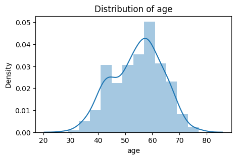

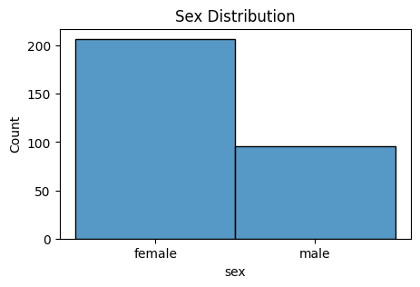

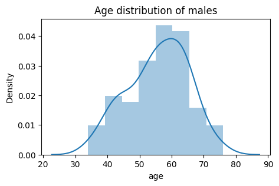

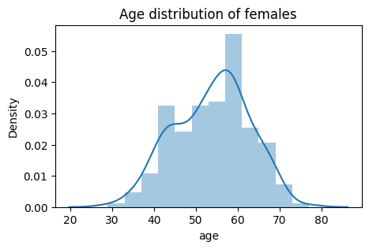

```python
plt.figure(figsize=(5,3))
plt.title('Distribution of age')
sns.distplot(df.age)

data=df.copy()
data.loc[data.sex==1]='female'
data.loc[data.sex==0]='male'
plt.figure(figsize=(5,3))
plt.title('Sex Distribution')
sns.histplot(data=data.sex)

male= df.loc[df.sex==0]
female= df.loc[df.sex==1]
plt.figure(figsize=(5,3))
plt.title('Age distribution of males')
sns.distplot(male.age)

plt.figure(figsize=(5,3))
plt.title('Age distribution of females')
sns.distplot(female.age)
```

From the distribution of the age, I can say the age group of most of the people in our data falls within around 40years to 70 years which makes is a suitable data to investigate heart attack since men aged 45 and older and women aged 55 and older are more likely to have a heart attack than are younger men and women

```python
df.cp.unique()
```

```
array([3, 2, 1, 0], dtype=int64)
```

Now let us have a look at the proportion of the different types of chest pains reported.

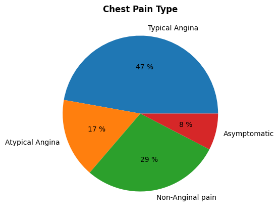

```python
plt.figure(figsize=(9,5))
plt.title('Chest Pain Type', fontdict={'fontweight': 'bold'})
typical_angina=df.loc[df.cp==0].count()[0]
atypical_angina=df.loc[df.cp==1].count()[0]
non_anginal= df.loc[df.cp==2].count()[0]
Asymptomatic= df.loc[df.cp==3].count()[0]

label=['Typical Angina','Atypical Angina', 'Non-Anginal pain', 'Asymptomatic']

plt.pie([typical_angina,atypical_angina,non_anginal,Asymptomatic], labels= label, autopct= '%.0f %%')
plt.show()
```

Typical Angina is a type of chest pain caused by reduced blood flow to the heart which makes it a strong indicator of heart disease and can help identify patients at higher risk for a heart attack. Atypical Angina and Non-Anginal Pain can also be symptoms of heart disease and should not be overlooked. Asymptomatic individuals with heart disease may not present with chest pain, making it important to consider other risk factors and diagnostic tests. So from the plot,the types of chest pains show that 47% of the people are more likely to develop heart attack faster with the rest also being likely develop heart attack.

Visualing the the distribution of cholesterol level.

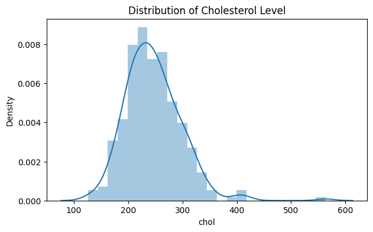

```python
plt.figure(figsize=(7,4))
plt.title('Distribution of Cholesterol Level')
sns.distplot(df.chol)
plt.show()
```

Let us have a look at the fasting blood sugar levels

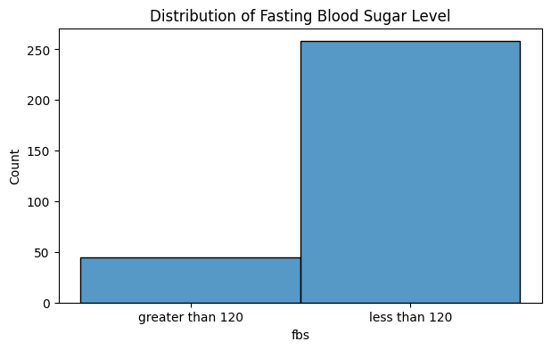

```python
data=df.copy()
data['fbs']=data['fbs'].replace({0: 'less than 120', 1:'greater than 120'})


plt.figure(figsize=(7,4))
plt.title('Distribution of Fasting Blood Sugar Level')
sns.histplot(data.fbs)
plt.show()
```

The data do not specify the actual levels for individuals but from this, we can determine their diabetes status; A fasting blood sugar level of 99 mg/dL or lower is normal, 100 to 125 mg/dL indicates you have prediabetes, and 126 mg/dL or higher indicates you have diabetes. So very few people in the data are diabetic, approximately 50 in number.Individuals with diabetes are at higher risk for developing heart disease and heart attack, as high blood sugar levels can damage the blood vessels and increase the buildup of plaque in the arteries.

## Analayzing relationships

Let have a look at the relationship between age and cholesterol level males and females.

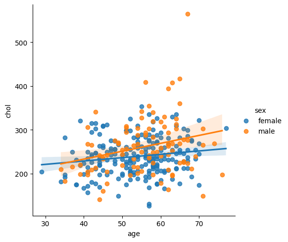

```python
data=df.copy()
data['sex']= data['sex'].replace({1:'female', 0:'male'})

sns.lmplot(x='age',y= 'chol',hue='sex' ,data=data)
```

From the plot,we could see that for males, cholesterol level has a positive correlation with age and thus, increases with age generally(remember other factors like alcohol intake are not considered here). Also,with female, there is a positive correlation between cholesterol level and age but it is lower at most ages compared to the cholesterol level of males.

Let us have a look at the relationship between age and resting blood pressure for males and females.

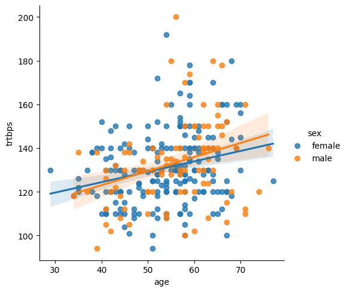

```python
sns.lmplot(x='age',y= 'trtbps',hue='sex' ,data=data)
```

The plot shows that generally, the resting blood pressure increases with age. For males, resting blood pressure's dependence on age is higher than females. The increase in resting blood pressure with age may be due to factors such as stiffening of the arteries, decreased elasticity of the blood vessels, and increased plaque buildup in the arteries. This can lead to an increased workload on the heart and a higher risk of heart disease and heart attack. Therefore, monitoring blood pressure and taking steps to maintain healthy blood pressure levels can be important for preventing heart disease and heart attack.

Let's see how blood sugar level and age are related too.

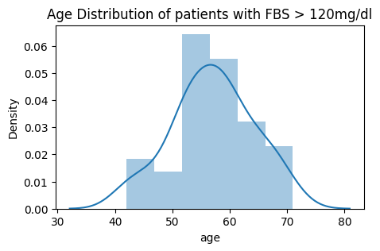

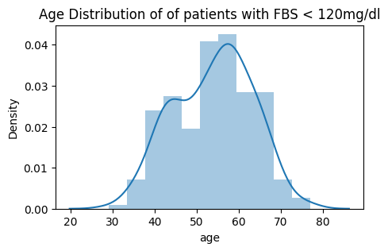

```python
data=df.copy()
diabetic=data.loc[data.fbs==1]
non_diabetic= data.loc[data.fbs==0]

plt.figure(figsize=(5,3))
plt.title('Age Distribution of patients with FBS > 120mg/dl')
sns.distplot(diabetic.age)
plt.figure(figsize=(5,3))
plt.title('Age Distribution of of patients with FBS < 120mg/dl')
sns.distplot(non_diabetic.age)
```

From the plots we could know that age distribution of people with fasting blood sugar levels greater 120mg/dl has a higher density at ages above 50years whiles age distribution for those with FBS lower that 120mg/dl has a higher density for a wider age range. Patients with FBS greater that 120 mg/dl are likely to be diabetic and develop heart attack faster. Fasting blood sugar (FBS) levels tend to increase with age due to changes in insulin resistance and decreased pancreatic function. This can increase the risk of developing diabetes, which is a major risk factor for heart disease and heart attack.

Now let us have a look as to whether there is a relationship between cholesterol level and resting blood pressure,and their role in determining the chance of a person developing heart attack.

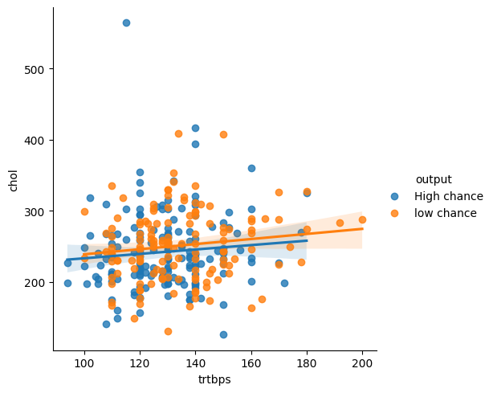

```python
data=df.copy()
data['output']= data['output'].replace({1:'High chance',0:'low chance'})
sns.lmplot(x='trtbps',y= 'chol', hue='output',data=data)
```

The plot shows that for both patients with high and low chance of developing heart attack, cholesterol levels has a positive correlation. Increased cholesterol levels can lead to atherosclerosis and narrowing of the arteries, which can contribute to higher resting blood pressure due to increased resistance to blood flow.

## Model to predict chance of heart attack.

```python
from sklearn.ensemble import RandomForestClassifier
from sklearn.metrics import mean_absolute_error
from sklearn.model_selection import train_test_split
from sklearn.linear_model import PassiveAggressiveRegressor
```

```python
X= df.drop(columns=['output'])
y=df.output

X_train,X_test,y_train,y_valid= train_test_split(X,y,test_size=0.2,random_state=72)

my_model= RandomForestClassifier(n_estimators=500 , max_depth= 100, random_state=72)

my_model.fit(X_train,y_train)
predictions = my_model.predict(X_test)

efficiency = my_model.score(X_test, y_valid)

mae= mean_absolute_error(y_valid,predictions)
print('model accuracy:', efficiency)
print('mean absolute error:', mae)
```

```
model accuracy: 0.8852459016393442
mean absolute error: 0.11475409836065574
```

## Testing

Now let us predict the chance of a person developing heart attack by giving inputs into the machine learninbg model:

```python
df.columns
```

```
Index(['age', 'sex', 'cp', 'trtbps', 'chol', 'fbs', 'restecg', 'thalachh',
       'exng', 'oldpeak', 'slp', 'caa', 'thall', 'output'],
      dtype='object')
```

```python
feature= np.array([[45,0,3,140,100,1,1,180,5,3,1,3,2,]])
my_model.predict(feature)
```

```
array([1], dtype=int64)
```

Reference

- Google

# THANK YOU

Daniel Appiah